# Logistic Regression

RG

2023-07-04

## Cancer and bird keeping

A 1972-1981 health survey in The Hague, Netherlands, discovered an association between keeping pet birds and increased risk of lung cancer. To investigate birdkeeping as a risk factor, researchers conducted a *case-control* study of patients in 1985 at four hospitals in The Hague (population 450,000). They identified 49 cases of lung cancer among the patients who were registered with a general practice, who were age 65 or younger and who had resided in the city since 1965. They also selected 98 controls from a population of residents having the same general age structure.

Format:

```
 A data frame with 147 observations on the following 7 variables.

 **LC** Whether subject has lung cancer

 **FM** Sex of subject

 **SS** Socioeconomic status, determined by occupation of the
      household's principal wage earner

 **BK** Indicator for birdkeeping (caged birds in the home for more than 6 consecutive months from 5 to 14 years before diagnosis (cases) or examination (control))

 **AG** Age of subject (in years)

 **YR** Years of smoking prior to diagnosis or examination

 **CD** Average rate of smoking (in cigarettes per day)
```

Source:

```
 Ramsey, F.L. and Schafer, D.W. (2013). _The Statistical Sleuth: A
 Course in Methods of Data Analysis (3rd ed)_, Cengage Learning.
```

References:

```
 Holst, P.A., Kromhout, D. and Brand, R. (1988).  For Debate: Pet
 Birds as an Independent Risk Factor for Lung Cancer, _British
 Medical Journal_ *297*: 13-21.
```

```r
load("case2002.rda")
str(case2002)
```

```
## 'data.frame':    147 obs. of  7 variables:
##  $ LC: Factor w/ 2 levels "LungCancer","NoCancer": 1 1 1 1 1 1 1 1 1 1 ...
##  $ FM: Factor w/ 2 levels "Female","Male": 2 2 2 2 2 2 2 2 2 2 ...
##  $ SS: Factor w/ 2 levels "High","Low": 2 2 1 2 2 1 1 2 2 1 ...
##  $ BK: Factor w/ 2 levels "Bird","NoBird": 1 1 2 1 1 2 1 2 1 2 ...
##  $ AG: int  37 41 43 46 49 51 52 53 56 56 ...
##  $ YR: int  19 22 19 24 31 24 31 33 33 26 ...
##  $ CD: int  12 15 15 15 20 15 20 20 10 25 ...
```

```r
     ## EXPLORATION AND MODEL BUILDING
## recode the Birdkeeping/Lung Cancer variable
     myCode <- ifelse(case2002$BK=="Bird" & case2002$LC=="LungCancer","Bird & Cancer",
       ifelse(case2002$BK=="Bird" & case2002$LC=="NoCancer","Bird & No Cancer",
       ifelse(case2002$BK=="NoBird" & case2002$LC=="LungCancer","No Bird & Cancer", "No Bird & No Cancer")))
table(myCode)
```

```
## myCode
##       Bird & Cancer    Bird & No Cancer    No Bird & Cancer No Bird & No Cancer
##                  33                  34                  16                  64
```

```r
table(myCode, case2002$LC, useNA="always")
```

```
##
## myCode                LungCancer NoCancer <NA>
##   Bird & Cancer               33        0    0
##   Bird & No Cancer             0       34    0
##   No Bird & Cancer            16        0    0
##   No Bird & No Cancer          0       64    0
##   <NA>                         0        0    0
```

- It is often useful to look at how the variables relate to each other. Two common methods are to use a *scatter plot matrix* to compare continuous (or presumed continuous) variables against each other.

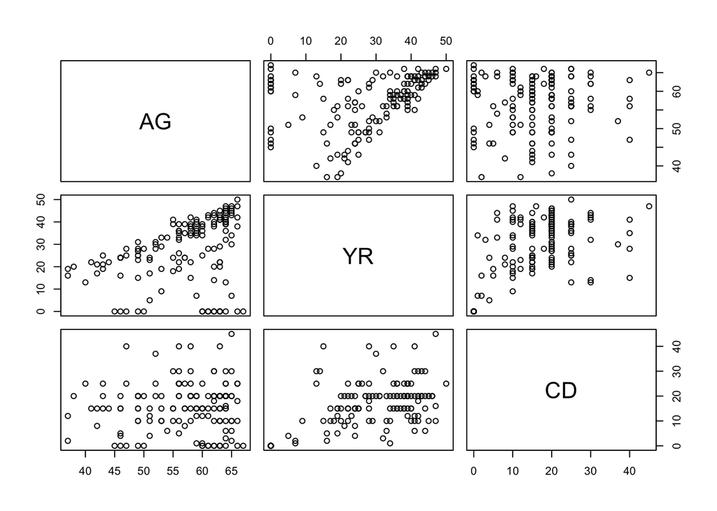

```r
pairs(case2002[,c("AG","YR","CD")])
```

**Exercise**

- comment on the relationship between age (AG) and years smoking (YR) [Hint: can you be a young smoker who has smoked for 40 years?]
- what do all the zeros for YR mean?
- notice that CD is very discrete, use the code below, and any other methods you want, to try to explain what is happening

```r
table(case2002$CD)
```

- any thoughts on the relationship between CD and YR

End of Exercise

Since with logistic regression we are really relating the probability that the individual is a case to the different covariages. Another fairly useful exploratory approach is to simply divide the continuous variable into some number of groups, by value, and then just compute the proportion of cases in each group.

```r
ageGp = cut(case2002$AG, breaks=4)
table(ageGp)
```

```
## ageGp
## (37,44.5] (44.5,52] (52,59.5] (59.5,67]
##        11        28        40        68
```

```r
##notice that this divides up the range but the groups
## are not the same size
q1 = quantile(case2002$AG, c(.25,.5,.75))
q1
```

```
## 25% 50% 75%
##  52  59  63
```

```r
ageGp2 = cut(case2002$AG, breaks=c(35, 52,59, 63, 70))
table(ageGp2)
```

```
## ageGp2
## (35,52] (52,59] (59,63] (63,70]
##      39      40      36      32
```

```r
##now our groups are fairly similar in size
## we can use split to create a list of the LC values by this discrete age grouping
spLC = split(case2002$LC, ageGp2)
sapply(spLC, function(x) sum(x == "LungCancer")/length(x))
```

```
##   (35,52]   (52,59]   (59,63]   (63,70]
## 0.3333333 0.3500000 0.3055556 0.3437500
```

**Exercise**

- repeat the above example for YR. You might find it easiest to make the non-smokers one group, and then for the smokers you have a more obvious interpretation.

## Discrete Variables

- You can compare discrete variables, or factors by examining two, or higher way way tables.

```r
mytab = table(case2002$FM, case2002$BK)
mytab
```

```
##
##          Bird NoBird
##   Female   22     14
##   Male     45     66
```

```r
prop.table(mytab)
```

```
##
##               Bird    NoBird
##   Female 0.1496599 0.0952381
##   Male   0.3061224 0.4489796
```

```r
##or proportions per row or column...
prop.table(mytab, margin=1)
```

```
##
##               Bird    NoBird
##   Female 0.6111111 0.3888889
##   Male   0.4054054 0.5945946
```

```r
chisq.test(mytab)
```

```
##
##  Pearson's Chi-squared test with Yates' continuity correction
##
## data:  mytab
## X-squared = 3.8451, df = 1, p-value = 0.04989
```

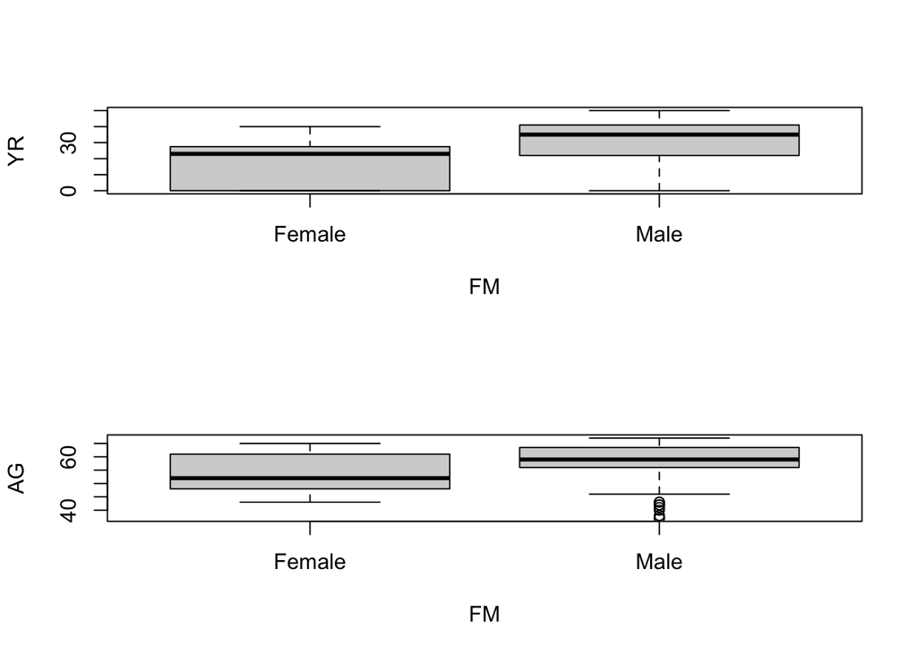

```r
    par(mfrow=c(2,1))
    boxplot(YR ~ FM, data=case2002)
    boxplot(AG ~ FM, data=case2002)
```

In the code below we change the levels so that cancer is the *risk* group.

```r
     # Reorder the levels so that the model is for log odds of cancer
     case2002$LC <- factor(case2002$LC, levels=c("NoCancer","LungCancer"))
     myGlm <- glm(LC ~ FM + SS + AG + YR + CD + BK, family=binomial, data=case2002)
     summary(myGlm)
```

```
##
## Call:
## glm(formula = LC ~ FM + SS + AG + YR + CD + BK, family = binomial,
##     data = case2002)
##
## Deviance Residuals:
##     Min       1Q   Median       3Q      Max
## -1.5642  -0.8333  -0.4605   0.9808   2.2460
##
## Coefficients:
##             Estimate Std. Error z value Pr(>|z|)
## (Intercept)  0.09196    1.75465   0.052 0.958204
## FMMale      -0.56127    0.53116  -1.057 0.290653
## SSLow       -0.10545    0.46885  -0.225 0.822050
## AG          -0.03976    0.03548  -1.120 0.262503
## YR           0.07287    0.02649   2.751 0.005940 **
## CD           0.02602    0.02552   1.019 0.308055
## BKNoBird    -1.36259    0.41128  -3.313 0.000923 ***
## ---
## Signif. codes:  0 '***' 0.001 '**' 0.01 '*' 0.05 '.' 0.1 ' ' 1
##
## (Dispersion parameter for binomial family taken to be 1)
##
##     Null deviance: 187.14  on 146  degrees of freedom
## Residual deviance: 154.20  on 140  degrees of freedom
## AIC: 168.2
##
## Number of Fisher Scoring iterations: 5
```

It appears that there’s an effect of Years of Smoking and of Bird Keeping after accounting for other variables; no obvious effects of other variables

**Exercise:**

- is the risk for cancer higher for men than for women?
- how could you *check* that result using a two-way table?
- discuss the terms in the model

## Model building

- Backward eliminiation is a method for model building that leaves out the least significant variable in the previous model, provided that *p*-value meets some minimal threshold, say less than $0.05$.
- in the model above the least significant variable is SS, so we remove it and refit

```r
     # Logistic regression model building using backward elimination (witholding BK)
     myGlm1 <- glm(LC ~ FM + AG + YR + CD + BK, family=binomial, data=case2002)
     summary(myGlm1)
```

```
##
## Call:
## glm(formula = LC ~ FM + AG + YR + CD + BK, family = binomial,
##     data = case2002)
##
## Deviance Residuals:
##     Min       1Q   Median       3Q      Max
## -1.5663  -0.8351  -0.4675   0.9764   2.2322
##
## Coefficients:
##             Estimate Std. Error z value Pr(>|z|)
## (Intercept) -0.03540    1.66342  -0.021 0.983020
## FMMale      -0.53657    0.51964  -1.033 0.301796
## AG          -0.03884    0.03528  -1.101 0.270881
## YR           0.07187    0.02610   2.754 0.005887 **
## CD           0.02632    0.02545   1.034 0.301084
## BKNoBird    -1.35212    0.40837  -3.311 0.000929 ***
## ---
## Signif. codes:  0 '***' 0.001 '**' 0.01 '*' 0.05 '.' 0.1 ' ' 1
##
## (Dispersion parameter for binomial family taken to be 1)
##
##     Null deviance: 187.14  on 146  degrees of freedom
## Residual deviance: 154.25  on 141  degrees of freedom
## AIC: 166.25
##
## Number of Fisher Scoring iterations: 5
```

```r
     myGlm2 <- update(myGlm1, ~ . - YR)
     summary(myGlm2)
```

```
##
## Call:
## glm(formula = LC ~ FM + AG + CD + BK, family = binomial, data = case2002)
##
## Deviance Residuals:
##     Min       1Q   Median       3Q      Max
## -1.7359  -0.8170  -0.5735   1.0798   2.1433
##
## Coefficients:
##             Estimate Std. Error z value Pr(>|z|)
## (Intercept) -1.59639    1.51944  -1.051 0.293424
## FMMale      -0.14002    0.47877  -0.292 0.769943
## AG           0.01311    0.02738   0.479 0.632186
## CD           0.05941    0.02172   2.735 0.006234 **
## BKNoBird    -1.47156    0.39735  -3.703 0.000213 ***
## ---
## Signif. codes:  0 '***' 0.001 '**' 0.01 '*' 0.05 '.' 0.1 ' ' 1
##
## (Dispersion parameter for binomial family taken to be 1)
##
##     Null deviance: 187.14  on 146  degrees of freedom
## Residual deviance: 164.10  on 142  degrees of freedom
## AIC: 174.1
##
## Number of Fisher Scoring iterations: 4
```

##Exercise - repeat until only significant variables are in the model

- forward selection works the other way - you fit a model with each variable in turn and then pick the one that has the most signficiant coefficient
- step 2 in forward selection is to then fit models with that first variable and each of the others (so a two variable model) and select the one that has the best fit
- repeat until no variables significantly improve the model

## Interactions

Sometimes the relationships between variables is not so simple. We might think that in our model the effect of birdkeeping is different for men and women, for example.

```r
     myGlm3 = glm(LC ~ FM + AG + CD + FM*BK + BK, family=binomial, data=case2002)
     summary(myGlm3)
```

```
##
## Call:
## glm(formula = LC ~ FM + AG + CD + FM * BK + BK, family = binomial,
##     data = case2002)
##
## Deviance Residuals:
##     Min       1Q   Median       3Q      Max
## -1.7168  -0.8235  -0.5668   1.0739   2.1268
##
## Coefficients:
##                 Estimate Std. Error z value Pr(>|z|)
## (Intercept)     -1.57594    1.52370  -1.034  0.30100
## FMMale          -0.25301    0.57490  -0.440  0.65987
## AG               0.01408    0.02760   0.510  0.60995
## CD               0.05952    0.02173   2.739  0.00617 **
## BKNoBird        -1.75728    0.90697  -1.938  0.05268 .
## FMMale:BKNoBird  0.35491    1.00062   0.355  0.72282
## ---
## Signif. codes:  0 '***' 0.001 '**' 0.01 '*' 0.05 '.' 0.1 ' ' 1
##
## (Dispersion parameter for binomial family taken to be 1)
##
##     Null deviance: 187.14  on 146  degrees of freedom
## Residual deviance: 163.97  on 141  degrees of freedom
## AIC: 175.97
##
## Number of Fisher Scoring iterations: 4
```

So what happened here? We added an interaction term and suddenly our main effects seem to go away. This is typical of situations where the covariates in the model are correlated. Adding a variable, or taking one out, changes all the coefficients.

The usual interpretation of $\beta_j$, that it is a the change in logit for a one unit change in the $j^{th}$ covariate, with all others held constant is problematic. As we noted for the relationship between AG and YR, if AG increases then so does YR for any smoker.

If we had a big enough cohort (think NHANES or UKBB) then we could try to look at the effect of changes in YR for a subanalysis where we keep age constant (or close to constant).

You could say take people between 48 and 52, and then fit a model with YR, but not include AG since you really restricted the range and see if YR is important. You could do it the other way, take some range of YR, then fit a model with AG but not YR and see what the AG coefficient is.

These challenges are the really hard part of being a statistician (and probably a data scientist as well). They matter quite a lot as we give substantial advice on risks and behaviour to the population, we should try to be sure we are correctly interpreting the data at hand.

And of course, one really needs replication (see below) in an independent data set to help ensure validity.

```r
     ## INFERENCE AND INTERPRETATION
     myGlm5 <- update(myGlm4, ~ . + BK, data=case2002)    # Now add bird keeping
     summary(myGlm5)


  ## INFERENCE AND INTERPRETATION
     myGlm5 <- update(myGlm4, ~ . + BK, data=case2002)    # Now add bird keeping
     summary(myGlm5)
     myGlm6 <- update(myGlm5, ~ . + BK:YR + AG:YR, data=case2002) # Try interaction terms
     anova(myGlm6,myGlm5) # Drop-in-deviance = 1.61 on 2 d.f.
     1 - pchisq(1.61,2)    # p-value = .45: no evidence of interaction
     anova(myGlm4,myGlm5)   # Test for bird keeping effect
     (1 - pchisq(12.612,1))/2  # 1-sided p-value: 0.0001916391

     case2002$BK <- factor(case2002$BK, levels=c("NoBird", "Bird"))  # Make "no bird" the ref level
     myGlm5b <- glm(LC ~ AG + YR + BK, family=binomial, data=case2002)
     beta <- myGlm5b$coef  # Extract estimated coefficients
     exp(beta[4])   # 3.961248
     exp(confint(myGlm5b,4))   # 1.836764 8.900840
     # Interpretation: The odds of lung cancer for people who kept birds were
     # estimated to be 4 times the odds of lung cancer for people of similar age, sex,
     # smoking history, and socio-economic status who didn't keep birds
     # (95% confidence interval for this adjusted odds ratio: 1.8 times to 8.9 times).

     # See bestglm library for an alternative variable selection technique.
```

[output not shown]

## And the study replicated…

- but there are other studies that failed to replicate…so how do we figure out what the real truth is

[figure not shown]